# Workflow 2 - Downloading Google Street View Images of LDD Buildings

## Aim

- For downloading large quantities of Online Image Data
- Introducing the Google Street View and Meta APIs
- Quality and validation of Image and Address Data
- Open Source vs Proprietry Licensing Pros and Cons

## Method

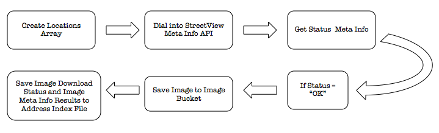

### Setup

```python
import pandas as pd
import numpy as np
from IPython.display import Image
## Load Librarys and Jupyter User Settings
from IPython.core.display import display, HTML
from IPython.display import Markdown, display, HTML
display(HTML("<style>.container { width:760 !important; }</style>"))
from IPython.display import Image as Img
import json
```

```python
## Image Thumb Gallery Label Helper
def css_styling():
    styles = open('custom_thumbs.css', 'r').read()
    return HTML(styles)
css_styling()
```

```python
## Table Label Helper
def printmd(string):
    display(Markdown(string))
```

### Load and Inspect Master Location File

```python
#Load CSV
#Includes stripping for NULLs

#New London
df_ldd = pd.read_csv('/Users/anthonysutton/ml2/_DATA_LABELS/LDD_STORE/LDD_MODEL/AB_LDD.csv',  sep=',',
                           error_bad_lines=False, index_col=False,  na_values=['.'], encoding="ISO-8859-1")

# Occasional Second Clean up required with these large python created csvs:
df_ldd.dropna()

#Visual Check of DataFrame:
#printmd('<br><b>`The LDD Master Dataset`</b> &#9663;<br><br>')
df_ldd.shape
pd.set_option('display.max_columns', 500)
df_ldd.head(1)

# sample size only
df_ldd = df_ldd.head(10)
```

### Create and Load Up X&Y Location Array

```python
import csv

# Open the file, grab the lat and lon values as floats,
# and store in the "locations" array.

locations = []
responses = []

with open('/Users/anthonysutton/ml2/_DATA_LABELS/LDD_STORE/LDD_MODEL/AB_LDD.csv',
          encoding = "ISO-8859-1") as csvfile:
#/Users/anthonysutton/ml2/_LDD_EXPLORER/JULY13_RUN/ldd_totalafford_plus10.csv
#/Users/anthonysutton/ml2/_LDD_EXPLORER/JULY13_RUN/ldd_totalafford0_resiplus10_notjoined.csv!!!
#/Users/anthonysutton/ml2/_LDD_EXPLORER/JULY13_RUN/ldd_totalafford0_resiplus10.csv
#/Users/anthonysutton/ml2/_LDD_EXPLORER/JULY13_RUN/ldd_totalresi_less10.csv
#/Users/anthonysutton/ml2/_LDD_EXPLORER/JULY13_RUN/ldd_totalresi_plus10.csv

    reader = csv.reader(csvfile)

    is_first_row = True
    for row in reader:
        # Skip the first row.
        if is_first_row:
            is_first_row = False
            continue


        #col, lat, lon = str(row[1]),  float(row[51]), float(row[52])
        col, post, lat, lon = str(row[2]), str(row[17]),  str(row[46]), str(row[47])
        #if int(col)> 100242 & int(col)< 100246:
        #if (int(col)> 1 and int(col)< 480):
        if "BR"in str(post):
        #& int(col)  < 138647
            location = (col, lat, lon,  post)
            #print("location="+ str(location))
            locations.append(location)


print ("Done")
locations = locations[:10]
```

```
Done
```

```python
#Check Array Count
len(locations)
```

```
10
```

### Google StreetView Static API

- The Street View Static API lets you embed a static (non-interactive) Street View panorama or thumbnail into your web page, without the use of JavaScript. The viewport is defined with URL parameters sent through a standard HTTP request, and is returned as a static image

#### Required parameters

- location:
  - Can be either a text string (such as Chagrin Falls, OH) or a lat/lng value (40.457375,-80.009353). The Street View Static API will snap to the panorama photographed closest to this location. When an address text string is provided, the API may use a different camera location to better display the specified location. When a lat/lng is provided, the API searches a 50 meter radius for a photograph closest to this location. Because Street View imagery is periodically refreshed, and photographs may be taken from slightly different positions each time, it's possible that your location may snap to a different panorama when imagery is updated.
- pano:
  - Is a specific panorama ID. These are generally stable.
- size:
  - specifies the output size of the image in pixels. Size is specified as {width}x{height} - for example, size=600x400 returns an image 600 pixels wide, and 400 high.
- key:
  - allows you to monitor your application's API usage in the Google Cloud Platform Console, and ensures that Google can contact you about your application if necessary. For more information, see Get a Key and Signature.

https://developers.google.com/maps/documentation/streetview/intro

### Google StreetView Image Metadata

- The Street View Static API metadata requests provide data about Street View panoramas. Using the metadata, you can find out if a Street View image is available at a given location, as well as getting programmatic access to the latitude and longitude, the panorama ID, the date the photo was taken, and the copyright information for the image. Accessing this metadata allows you to customize error behavior in your application.

#### Required parameters

- location:
  - can be either a text string (such as Chagrin Falls, OH) or a comma-separated pair of latitude/longitude coordinates (40.457375,-80.009353).
- pano:
  - a specific panorama ID. These are generally stable, though panoramas may change ID over time as imagery is refreshed.
- key or client and signature:
  - the API key or client ID are credentials required to authenticate the request. The digital signature is also required in certain instances. For more information, see Get a Key and Signature.

https://developers.google.com/maps/documentation/streetview/intro

# Step 1 - Using Google StreetView Meta Info API

### Notes:

> - Multiple Batch Downloading Attempts
> - Trial Runs, Network Traffic, PC Performance Issues
> - Licensing Cost Increases Mid Project(from Free to $5 per 1000)
> - Save Meta Data to File for Subsequent Batch Download attempts

### Dial in and Get Image Meta Info

```python
import urllib.request
from urllib.parse import quote
#from urllib.parse import urlparse

# Put your Google Street View API key here.
#api_key = ""

api_key = "AIzaSyD_O9mUG_8vdZmsGWp-Iiwo72K95c3XkTY"

#AIzaSyD_O9mUG_8vdZmsGWp-Iiwo72K95c3XkTY

#api_url = "https://maps.googleapis.com/maps/api/streetview?size=640x640&location={0},{1}&pitch=10&fov=120&source=outdoor&key={2}"
#api_url = "https://maps.googleapis.com/maps/api/streetview?size=640x640&location={0},{1}&source=outdoor&key={2}"
api_url_meta = "https://maps.googleapis.com/maps/api/streetview/metadata?&location={0},{1}&key={2}"


# Loop over every location, and for each location, loop over all the possible headings.

for location in locations:
    #for direction in headings:
    # Create the URL for the request to Google.
    col, lat, lon, post = location
    #url = api_url.format(quote(lat), quote(lon), api_key)
    #url = api_url.format(lat, lon, api_key)
    #print(url)
    meta_url = api_url_meta.format(lat, lon, api_key)

    #filename = "/Users/anthonysutton/ml2/_ACORN_EXPLORER/London_Labels3/col_id_" + col + ".jpg"

    # Use the 'curl' command to actually make the request and save the file to disk.
    #urllib.request.urlretrieve(url, filename)

    with urllib.request.urlopen(meta_url) as response:
            meta_resp = response.read()
            #print(meta_resp)
            #print(meta_resp.decode('utf-8'))
            #responded = (col, lat, lon, post, meta_resp.decode('utf-8').replace("'", '"'))
            responded = (col, lat, lon, post, meta_resp)
    #responded = (col, post, lat, lon)
            responses.append(responded)

    print(meta_url)
    #print(url)
    print(responded)
    #print(filename)

print ("Done")

#31061
#116
#38647
#100242
#116810
```

[output not shown]

**Limit Output** (NB Extension)

### Parse JSON and Save Response to File

```python
responses
```

[output not shown]

**Limit Output** (NB Extension)

```python
{
   "copyright" : "© 2017 Google",
   "date" : "2016-05",
   "location" : {
      "lat" : 48.85783227207914,
      "lng" : 2.295226175151347
   },
   "pano_id" : "tu510ie_z4ptBZYo2BGEJg",
   "status" : "OK"
}
```

```python
df_results = pd.DataFrame.from_records(responses)
```

```python
df_results.to_csv('ab_london_goo_sv_meta_4.csv')
```

```python
import json

#Unpack the JSON into Seperate Columns
df_json_parse = df_results.join(df_results['meta'].apply(json.loads).apply(pd.Series))
#Name Columns, For now we just get Status
meta_df = df_json_parse[['Index_Column_Key', 'lat', 'lon', 'post', 'meta', 'status']]
```

```python
meta_df.head(10)
```

[output not shown]

```python
#Save To File
meta_df.to_csv('ab_london_goo_sv_meta_2.csv')
```

```python
df_results = pd.read_csv('ab_london_goo_sv_meta_2.csv',  sep=',',
                           error_bad_lines=False, index_col=False,  na_values=['.'], encoding="ISO-8859-1")
```

```python
df_results.head()
```

|  | Unnamed: 0 | Index_Column_Key | lat | lon | post | meta | status |
| --- | --- | --- | --- | --- | --- | --- | --- |
| 0 | 0 | 44 | 0.175171 | RM7 0TB | 51.561274 | b'{\n "copyright" : "\xc2\xa9 Google",\n "... | OK |
| 1 | 1 | 25 | 0.166758 | RM10 7AP | 51.554874 | b'{\n "copyright" : "\xc2\xa9 Google",\n "... | OK |
| 2 | 2 | 45 | 0.155159 | RM10 7YT | 51.551508 | b'{\n "copyright" : "\xc2\xa9 Google",\n "... | OK |
| 3 | 3 | 37 | 0.140977 | RM9 | 51.524699 | b'{\n "copyright" : "\xc2\xa9 Google",\n "... | OK |
| 4 | 4 | 21 | 0.155387 | RM9 | 51.542592 | b'{\n "status" : "ZERO_RESULTS"\n}\n' | ZERO_RESULTS |

**Start Here:** for Subsequent Batch Download Attempts

# Step 2 - Using Google StreetView Static API to Download Images

### Load and Inspect Meta Results File

```python
#df.to_csv('/Users/anthonysutton/ml2/_ACORN_EXPLORER/final_acorn_label_upload9_results2.csv')

#Load CSV
#Includes stripping for NULLs
df_results = pd.read_csv('/Users/anthonysutton/ml2/_ACORN_EXPLORER/final_acorn_label_upload9_results.csv',  sep=',',
                           error_bad_lines=False, index_col=False,  na_values=['.'], encoding="ISO-8859-1")

#df_results = pd.read_csv('ab_london_goo_sv_meta_1.csv',  sep=',',
#                           error_bad_lines=False, index_col=False,  na_values=['.'], encoding='utf-8')
```

```python
df_results.head()
#df_results['meta'].str.decode('utf-8')
```

|  | Unnamed: 0 | Index_Column_Key | post | lat | lon | meta |
| --- | --- | --- | --- | --- | --- | --- |
| 0 | 1 | 1 | 51.403386 | 0.043619 | BR12AA | b'{\n "copyright" : "\xc2\xa9 Google, Inc.",... |
| 1 | 2 | 2 | 51.401750 | 0.054400 | BR12AB | b'{\n "copyright" : "\xc2\xa9 Google, Inc.",... |
| 2 | 3 | 3 | 51.404296 | 0.046650 | BR12AD | b'{\n "status" : "ZERO_RESULTS"\n}\n' |
| 3 | 4 | 4 | 51.403327 | 0.047555 | BR12AE | b'{\n "status" : "ZERO_RESULTS"\n}\n' |
| 4 | 5 | 5 | 51.405404 | 0.052709 | BR12AG | b'{\n "status" : "ZERO_RESULTS"\n}\n' |

### Only Load "Status == OK" Images into Locations Array

```python
df_json_parse_valid = df_json_parse[df_json_parse['status'] == 'OK']

#We can also use DATE AND RADIUS Google API Variables. E.g. Only use images from specific date ranges, or photos
#taken from specific distance,to avoid outliers. The efault is 50m

df_json_parse_valid.shape
df_json_parse_valid.head(1)
```

### Prepare JSON for Locations Array

```python
loc_loader = df_json_parse_valid[['Index_Column_Key', 'post', 'lat', 'lon']].values
```

```python
locations = loc_loader
locations
```

[output not shown]

### Create and Load Up X&Y Location Array

```python
# Open the file, grab the lat and lon values as floats,
# and store in the "locations" array.
#print("test")

locations = []
responses = []

#Old London Joined on Acorn Categories
with open('/Users/anthonysutton/ml2/_ACORN_EXPLORER/final_acorn_label_upload9_noblank.csv',
          encoding = "ISO-8859-1") as csvfile:
#/Users/anthonysutton/ml2/_LDD_EXPLORER/JULY13_RUN/ldd_totalafford_plus10.csv
#/Users/anthonysutton/ml2/_LDD_EXPLORER/JULY13_RUN/ldd_totalafford0_resiplus10_notjoined.csv!!!
#/Users/anthonysutton/ml2/_LDD_EXPLORER/JULY13_RUN/ldd_totalafford0_resiplus10.csv
#/Users/anthonysutton/ml2/_LDD_EXPLORER/JULY13_RUN/ldd_totalresi_less10.csv
#/Users/anthonysutton/ml2/_LDD_EXPLORER/JULY13_RUN/ldd_totalresi_plus10.csv

    #with open('/Users/anthonysutton/ml2/_DATA_LABELS/LDD_STORE/LDD MODEL/LDD_Geocode_LBTH.csv', R) as csvfile:


    reader = csv.reader(csvfile)

    is_first_row = True
    for row in reader:
        # Skip the first row.
        if is_first_row:
            is_first_row = False
            continue


        #col, lat, lon = str(row[1]),  float(row[51]), float(row[52])
        col, post, lat, lon = str(row[0]), str(row[2]),  str(row[15]), str(row[16])
        #if int(col)> 100242 & int(col)< 100246:
        if (int(col)> 1 and int(col)< 20):
            #and "BR"in str(post)):
            #& int(col)  < 138647
            location = (col, lat, lon,  post)
            #print("location="+ str(location))
            locations.append(location)


print ("Done")
#locations = locations[:-1]
```

**Warning:** Check Parameters carefully before accessing the billable Google Street View API

```python
from urllib.parse import quote
#from urllib.parse import urlparse

# Put your Google Street View API key here.
#api_key = "AIzaSyD_O9mUG_8vdZmsGWp-Iiwo72K95c3XkTY"
#AIzaSyD_O9mUG_8vdZmsGWp-Iiwo72K95c3XkTY

#api_url = "https://maps.googleapis.com/maps/api/streetview?size=640x640&location={0},{1}&pitch=10&fov=120&source=outdoor&key={2}"

#api_url = "https://maps.googleapis.com/maps/api/streetview?size=640x640&location={0},{1}&source=outdoor&key={2}"

#api_url_meta = "https://maps.googleapis.com/maps/api/streetview/metadata?&location={0},{1}&key={2}"


# Loop over every location, and for each location, loop over all the possible headings.

for location in locations:
    #for direction in headings:
    # Create the URL for the request to Google.
    col, lat, lon, post = location
    #url = api_url.format(quote(lat), quote(lon), api_key)
    url = api_url.format(lat, lon, api_key)
    #print(url)
    meta_url = api_url_meta.format(lat, lon, api_key)

    filename = "/Users/anthonysutton/ml2/_ACORN_EXPLORER/London_Labels2/col_id_" + col + ".jpg"

    # Use the 'curl' command to actually make the request and save the file to disk.
    #urllib.request.urlretrieve(url, filename)

    #with urllib.request.urlopen(meta_url) as response:
            #meta_resp = response.read()

            #responded = (col, lat, lon, post, meta_resp)
    #responded = (col, post, lat, lon)
    #responses.append(responded)

    print(meta_url)
    print(url)
    print(responded)
    print(filename)

print ("Done")

#31061
#116
#38647
#100242
```

# Step 3 - Inspect Downloaded Image Data

```python
#Load CSV
#Includes stripping for NULLs
df_results = pd.read_csv('../../_ACORN_EXPLORER/final_acorn_label_upload9_results.csv',  sep=',',
                           error_bad_lines=False, index_col=False,  na_values=['.'], encoding="ISO-8859-1")
```

```python
#df_json_parse_valid[['Index_Column_Key', 'post', 'lat', 'lon']]
df_json_parse_valid = df_results
df_json_parse_valid.head(4)
```

|  | Unnamed: 0 | Index_Column_Key | post | lat | lon | meta |
| --- | --- | --- | --- | --- | --- | --- |
| 0 | 1 | 1 | 51.403386 | 0.043619 | BR12AA | b'{\n "copyright" : "\xc2\xa9 Google, Inc.",... |
| 1 | 2 | 2 | 51.401750 | 0.054400 | BR12AB | b'{\n "copyright" : "\xc2\xa9 Google, Inc.",... |
| 2 | 3 | 3 | 51.404296 | 0.046650 | BR12AD | b'{\n "status" : "ZERO_RESULTS"\n}\n' |
| 3 | 4 | 4 | 51.403327 | 0.047555 | BR12AE | b'{\n "status" : "ZERO_RESULTS"\n}\n' |

### Inspect Downloaded Images

```python
# Random Image Selection

#imagey = df_ldd_Filter1['TempID'].sample(n=1)
size =  1       # sample size
replace = True  # with replacement

# Load 10 Records for now..
df_json_parse_valid = df_json_parse_valid.head(10)
fn = lambda obj: obj.loc[np.random.choice(obj.index, size, replace),:]
thumb_gally = df_json_parse_valid.groupby('lon', as_index=False).apply(fn)

thumb_gally2 = thumb_gally[['Index_Column_Key', 'lon']].values


#thumbsdf = df_json_parse_valid.groupby('ClassificationCode').filter(lambda x : len(x)>100)
#fn = lambda obj: obj.loc[np.random.choice(obj.index, size, replace),:]
#thumb_gally = thumbsdf.groupby('ClassificationCode', as_index=False).apply(fn)
#thumb_gally2 = thumb_gally[['TempID', 'ClassificationCode']].values

gallery = ""

element = 2

for count, element in enumerate(thumb_gally2, 1):

    if thumb_gally2[count-1,0] <= 29192:
        inp2 = '../../_STREETVIEW_EXPLORER/LDD_Complete/col_id_' + str(thumb_gally2[count-1,0]) +'.jpg'
    else:
        inp2 = '../../_STREETVIEW_EXPLORER/LDD_Complete/batch2/col_id_' + str(thumb_gally2[count-1,0]) +'.jpg'
    #printmd("<div class='gallery'><td><img src='" +  inp2 + "' width='' height=''/></td></div>")
    inp3 = "<div class='gallery'><div class='zoom'><img src='" +  inp2 + "' width='' height=''></div><div class='desc'>" + thumb_gally2[count-1,1] + "</div></div>"
    gallery = gallery + inp3


display(HTML(gallery))
```

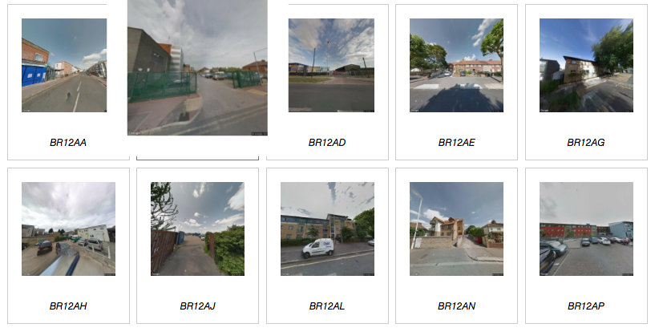

```python
#To Do: Write Up Code for Logging Sub Batch Download attempts
```

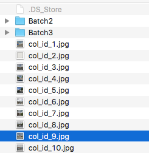